# Homework 02 Answers

Every Saturday, at the same time, a primatologist goes and sits in the forest in the morning and listens for titi monkey calls, counting the number of calls they hear in a 2 hour window from 5am to 7am. Based on previous knowledge, she believes that the mean number calls she will hear in that time is exactly 15. Let $X$ represent the appropriate Poisson random variable of the number of calls heard in each monitoring session.

- What is the probability that she will hear more than 8 calls during any given session?

As this is a count, we should use the Poisson distribution functions.

```r
call.prob <- 1 - ppois(q=8, lambda=15) # Since the ppois function does 8 or less, so therefore you need to do 1 - ppois to get probability of 8 or more
call.prob
```

```
## [1] 0.9625535
```

- What is the probability that she will hear no calls in a session?

```r
call.prob <- dpois(x=0, lambda=15)
call.prob
```

```
## [1] 3.059023e-07
```

- What is the probability that she will hear exactly 3 calls in a session?

```r
call.prob <- dpois(x=3, lambda=15)
call.prob
```

```
## [1] 0.0001720701
```

- Plot the relevant Poisson mass function over the values in range 0 ≤ X ≤ 30.

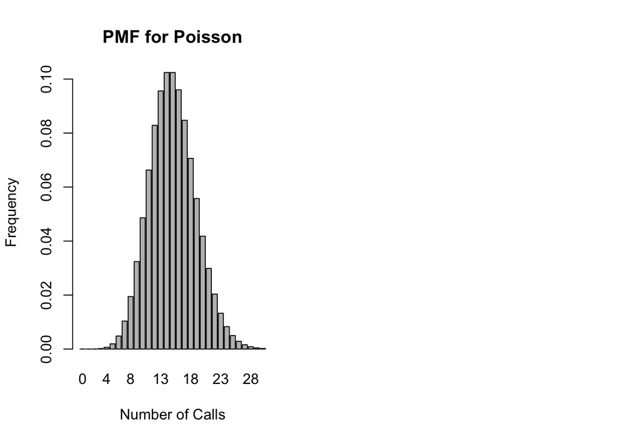

```r
par(mfrow=c(1,2))
barplot(dpois(x=0:30, lambda=15), main="PMF for Poisson", xlab="Number of Calls", ylab="Frequency", names.arg = 0:30)
```

- Simulate 104 results from this distribution (i.e., 2 years of Saturday monitoring sessions). Plot the simulated results using `hist()` and use `xlim()` to set the horizontal limits to be from 0 to 30. How does your histogram compare to the shape of the probability mass function you plotted above?

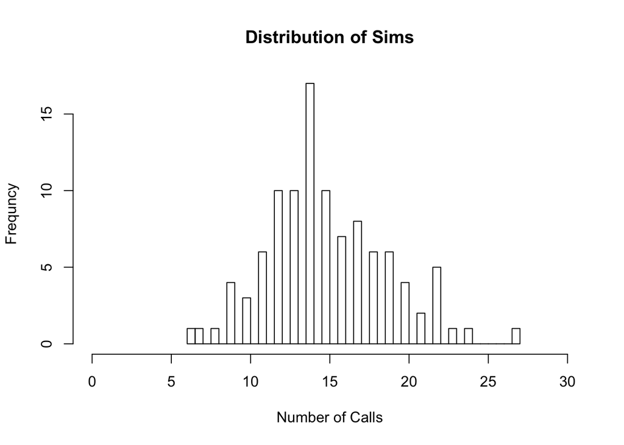

```r
sims <- rpois(n=104, lambda=15)
hist(sims, xlim=c(0,30), main="Distribution of Sims", xlab="Number of Calls", ylab="Frequncy", breaks=30, freq=TRUE)
```

```r
mean(sims)
```

```
## [1] 15.06731
```

```r
var(sims)
```

```
## [1] 15.05368
```

Both plots show a peak at ~15 calls and a variance of ~15.